# Diary_2025

Justin Holland

2025-01-05

## Janaury 2025

### 20250103 Friday

In Tassie from 17 Dec through 16 Jan. Daddy made a booking issue, Mummy’s car got left in Geelong.

Day trip to Gunns Plains caves and Wings Wildlife with Nanny and Pooppy. Nanny did awesome in the caves. Daddy carried Theo whole way, up and down steep steps and ladder. Another day where I’m very happy to be dad-fit.

Both boys had a great day, caves definitely worthwhile experience. Tour guide Ben is a rover and knows Amy.

Both kids loved the fish at Wings splashing them when being fed. Theo’s laugh was fantastic,

Both loved feeding the kangaroos as well. Theo didn’t want to leave.

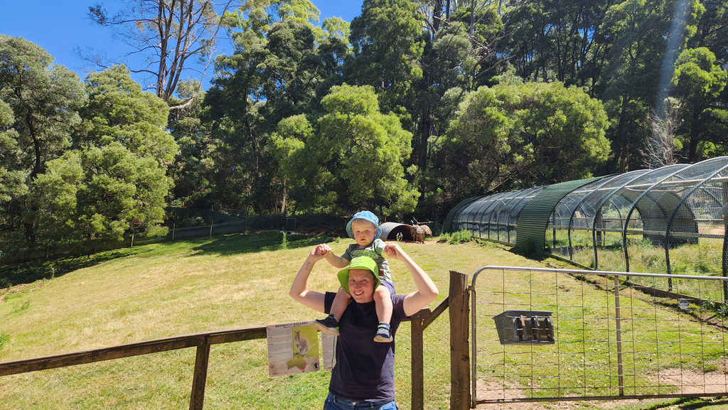

### 20250104 Saturday

Dinner at Little Sisters with live music. Kids played nicely with others. Walk home via the playground.

### 20250105 Sunday

Went to Fossil Bluff early in the day. James loved the fossils. Theo loved lying down in puddles.

Maddy, Rory, Matteo and Xander came over in the afternoon and kids played together really nicely.

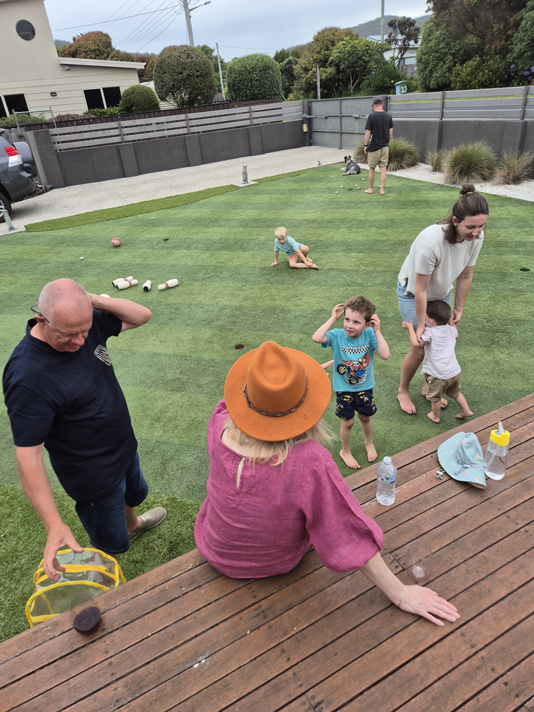

### 20250107 Tuesday

Moved to Adam and Brogan’s at Cradle Mountain Hotel but had a quiet day otherwise.

### 20250111 Saturday

Went to Lobster Ponds with Granny and Pa, first time for all of us. Tour by Kevin Hyland, former mayor of Winyard.

### 20250112 Sunday

Church in Burnie. Kids enjoyed running around with Taz and Lexi’s girls.

Theo’s language has been impressing eveeryone. Follows what being said really well, narrates the activities and plans and loves to repeat the plan to confirm his understanding of what is happening.

Theo is straigtening out, getting taller. looks like real little boy. getting heavier.

Did maths basic maths school stuff (subscrition given from Nick) yesterday with James, he is interested and doing well. recognises numbers and counts well up to mid teens.

Also played quacks again with Granny and James yesterday, added blue chips taking us up to 5 coulours. Not 100% sure James doesnt ’cheat; jsut a little but he is getting the logic and understadning the game quite well at least while concentration holds.

## February 2025

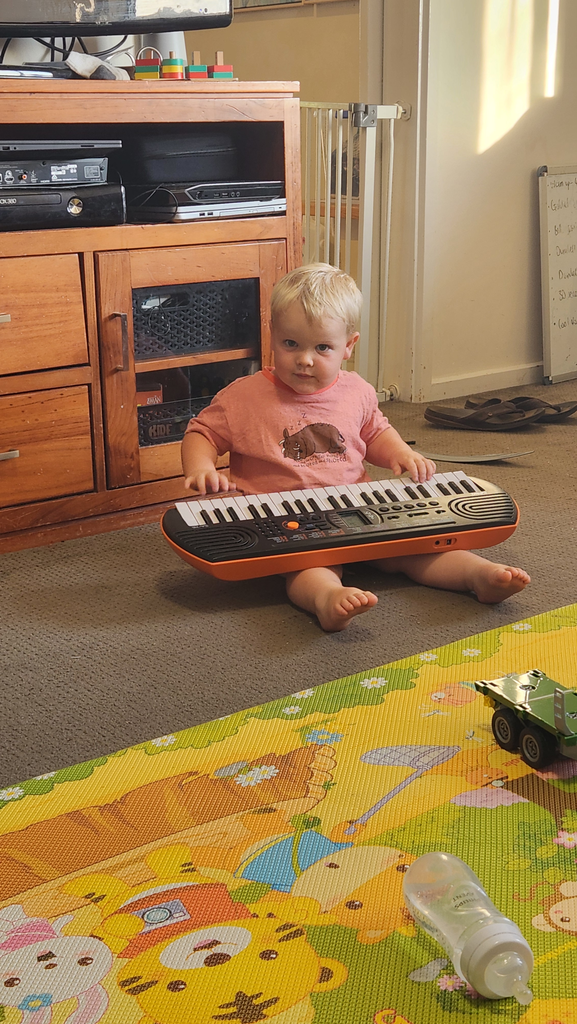

Last night with Nanny poppy here helping look after James before school starts and doing lots of pre-house-move work in the garden and babysitting while we try too.

Sitting here watching Theo use James keyboard, controlling it like a master, seriously playing piano to boppy ‘Ode to Joy’, seems like musical prodigy, playing to beet.

### 20250222 Saturday

Theo talking about being exctied for moving house. Trying to understand, asking things like “will Nanny and Poppy come to the new house? Will Granny and Pa come to the new house? and Phil will come to the new house? And Pippa and Lizzie will come to the new house” in his gorgeous little voice.

Nailing potty training.

James settled in well to school. Feels like a lovely environment. Watched Mr Bean last night and he was in stitches. Some more good chances to explain the jokes and what Mr Bean is doing wrong. I explained the pun in the christmas episode where the girlfriend asked if he had the turkey on and mr bean says something like “oh yes” when its really on his head. James thoguht it was hilarious when he understood it.

### 20250225 Tuesday

At school drop of James did not want me to go trhough the gate. When we got to the gate he just turned and pointed an said ‘go back to the car’. We clarified the situation and I agreed he could go by himself. On Friday he wanted me to sit and wait with him till the bell rang.

First night at Joeys (Scouts) tonight - scavenger hunt - James took to it with enthusiasm and seemed to do a good job of listening despite a litte bit of hyper energy.

Sitting down to watch ‘funny donkey’ with family, I asked Theo if I could sit with him (in my spot). He said carefully ‘of course you can’ in very lovely voice. Use of language is incredible.

### 20250813 Wednsday

James lovely at scouts last night. Nerf guns, did parade of second time. Well behaved, did sneak attacks on the flag more than shooting.

Nanny and Poppy staying. Theo very cuddly at night on the couch with Nanny.

Taking james to bed, read Monstosaurus, listened to a ‘Bluey Club’ and then went to put on the music and he asks for ’the music that made me go to sleep when I was a baby” (The Last Kingdom - Livstraedrir), not an uncommon occurrence. Love it that he gets special meaning from that song.

James Minecraft improving. He started building his own house and then Evie came to help him. Love it that we can hae this cousin-like relationship and spend time doing Minecraft together from a distance.

[figure not shown]

[figure not shown]

[figure not shown]